# CE083 - Estatística Computacional I

NOME Willian Meira Schlichta (GRR20159077)

25 de Junho de 2019

# Prova de aproveitamento de conhecimento

## Dados

O abalone é um gênero de moluscos gastrópodes marinhos, encontrado na costa de diversos países. É explorado comercialmente e é um alimento altamente valorizado em países asiáticos.

Os dados disponibilizados correspondem à diversos exemplares de abalone coletados na Tasmânia, em quatro áreas diferentes. Para cada indivíduo foram medidos o comprimento e determinado o número de anéis etários, para tentar se determinar a idade (cada anel etário corresponde à aproximadamente um ano de vida).

As variáveis são:

- `Area`: área de coleta (A, B, C, ou D)
- `Sexo`: sexo dos indivíduos (M = macho, F = fêmea, I = indeterminado)
- `Comprimento`: comprimento dos indivíduos (cm)
- `Aneis`: número de anéis etários

Faça a importação da base de dados:

```r
dados_abalone <- read.csv('dados_abalone.csv',header = TRUE, dec = '.')
```

Verifique sua estrutura e faça um sumário estatístico:

```r
str(dados_abalone)
```

```
## 'data.frame':    4177 obs. of  4 variables:
##  $ Area       : Factor w/ 4 levels "A","B","C","D": 1 1 1 1 1 1 1 1 1 1 ...
##  $ Sexo       : Factor w/ 3 levels "F","I","M": 3 3 1 3 2 2 1 1 3 1 ...
##  $ Comprimento: num  0.455 0.35 0.53 0.44 0.33 0.425 NA NA 0.475 0.55 ...
##  $ Aneis      : int  15 7 9 10 7 8 NA NA 9 19 ...
```

```r
summary(dados_abalone)
```

```
##  Area     Sexo      Comprimento        Aneis
##  A: 835   F:1307   Min.   :0.075   Min.   : 1.000
##  B: 919   I:1342   1st Qu.:0.450   1st Qu.: 8.000
##  C:1253   M:1528   Median :0.545   Median : 9.000
##  D:1170            Mean   :0.523   Mean   : 9.953
##                    3rd Qu.:0.615   3rd Qu.:11.000
##                    Max.   :0.815   Max.   :29.000
##                    NA's   :543     NA's   :543
```

Classifique as variáveis de acordo com suas características (ex.: qualitativa ordinal, etc)

- `Area`: Qualitativa Nominal
- `Sexo`: Qualitativa Nominal
- `Comprimento`: Quantitativa Continua
- `Aneis`: Quantitativa Discreta

## Análise exploratória

Faça uma tabela de frequência obsoluta com soma marginal para `Area`:

```r
tab_area <- table(dados_abalone$Area)
tab_area
```

```
##
##    A    B    C    D
##  835  919 1253 1170
```

Faça uma tabela de frequência relativa com soma marginal para `Sexo`:

```r
tab_sexo <- table(dados_abalone$Sexo)
tab_sexo/length(dados_abalone$Sexo)
```

```
##
##         F         I         M
## 0.3129040 0.3212832 0.3658128
```

Faça uma tabela de frequências absolutas com soma marginal entre as variáveis `Sexo` e `Area`:

```r
tab_sex_area <- with(dados_abalone, table(Sexo, Area))
tab_sex_area
```

```
##     Area
## Sexo   A   B   C   D
##    F 308 241 394 364
##    I 191 369 397 385
##    M 336 309 462 421
```

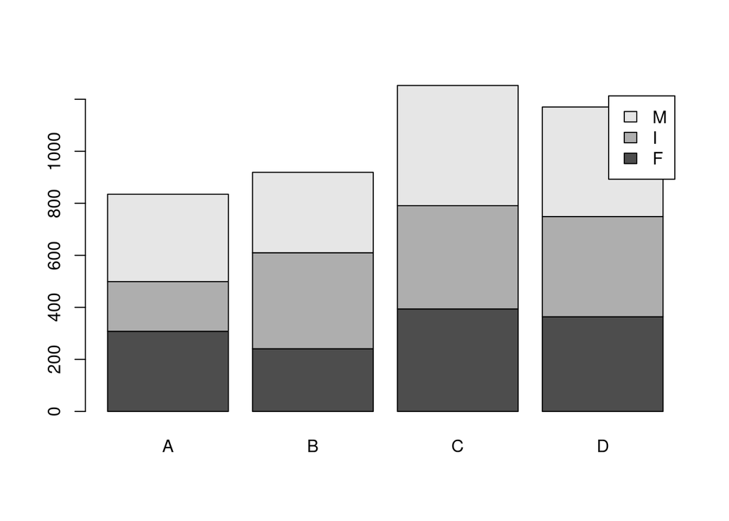

```r
barplot(tab_sex_area, legend = TRUE)
```

Em uma mesma janela gráfica, faça um histograma para `Comprimento` e outro para `Aneis`:’

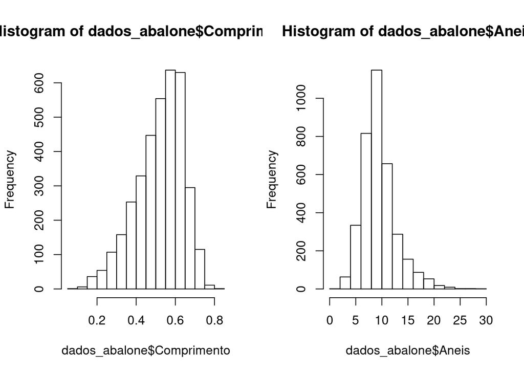

```r
par(mfrow = c(1,2))
hist(dados_abalone$Comprimento)
hist(dados_abalone$Aneis)
```

Faça um gráfico de dispersão entre `Comprimento` e `Aneis`. O número de anéis etários depende do comprimento do indivíduo. Com essa informação, determine corretamente as variáveis que devem estar no eixo Y (resposta ou dependente) e no eixo X (explicativa ou independente):

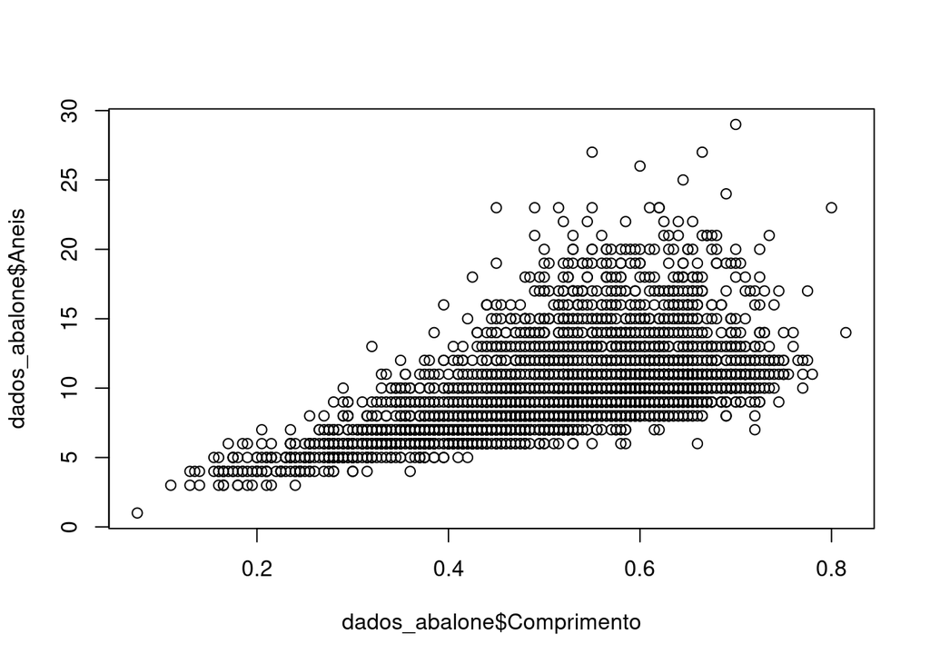

```r
plot(x = dados_abalone$Comprimento, y = dados_abalone$Aneis)
```

Verifique o tamanho efetivo da amostra, em relação à variàvel `Aneis`. Ou seja, verifique o número de elementos nessa coluna que não sejam valores perdidos:

```r
dados_sem_NA <- subset(dados_abalone, dados_abalone$Aneis != "NA")
length(dados_sem_NA$Aneis)
```

```
## [1] 3634
```

Calcule a média de `Aneis` e de `Comprimento` (separadamente ou com apenas uma função):

```r
mean(dados_sem_NA$Aneis)
```

```
## [1] 9.952669
```

```r
mean(dados_sem_NA$Comprimento)
```

```
## [1] 0.5230063
```

Calcule a variância de `Aneis` e de `Comprimento` (separadamente ou com apenas uma função):

```r
var(dados_sem_NA$Aneis)
```

```
## [1] 10.58515
```

```r
var(dados_sem_NA$Comprimento)
```

```
## [1] 0.0145447
```

Faça um sumário estatístico de `Aneis`, separado para cada `Area`:

```r
dados_A <- subset(dados_sem_NA, dados_sem_NA$Area == 'A')
summary(dados_A)
```

```
##  Area    Sexo     Comprimento         Aneis
##  A:738   F:268   Min.   :0.0750   Min.   : 1.00
##  B:  0   I:173   1st Qu.:0.4050   1st Qu.: 9.00
##  C:  0   M:297   Median :0.5050   Median :11.00
##  D:  0           Mean   :0.4866   Mean   :11.41
##                  3rd Qu.:0.5787   3rd Qu.:14.00
##                  Max.   :0.7450   Max.   :29.00
```

```r
dados_B <- subset(dados_sem_NA, dados_sem_NA$Area == 'B')
summary(dados_B)
```

```
##  Area    Sexo     Comprimento         Aneis
##  A:  0   F:211   Min.   :0.1400   Min.   : 3.000
##  B:790   I:318   1st Qu.:0.4750   1st Qu.: 7.000
##  C:  0   M:261   Median :0.5700   Median : 9.000
##  D:  0           Mean   :0.5433   Mean   : 8.754
##                  3rd Qu.:0.6288   3rd Qu.:10.000
##                  Max.   :0.8150   Max.   :17.000
```

```r
dados_C <- subset(dados_sem_NA, dados_sem_NA$Area == 'C')
summary(dados_C)
```

```
##  Area     Sexo     Comprimento         Aneis
##  A:   0   F:347   Min.   :0.1300   Min.   : 3.00
##  B:   0   I:352   1st Qu.:0.4550   1st Qu.: 8.00
##  C:1095   M:396   Median :0.5450   Median : 9.00
##  D:   0           Mean   :0.5273   Mean   : 9.84
##                   3rd Qu.:0.6200   3rd Qu.:11.00
##                   Max.   :0.8000   Max.   :27.00
```

```r
dados_D <- subset(dados_sem_NA, dados_sem_NA$Area == 'D')
summary(dados_D)
```

```
##  Area     Sexo     Comprimento         Aneis
##  A:   0   F:309   Min.   :0.1400   Min.   : 3.000
##  B:   0   I:327   1st Qu.:0.4550   1st Qu.: 8.000
##  C:   0   M:375   Median :0.5500   Median :10.000
##  D:1011           Mean   :0.5291   Mean   : 9.944
##                   3rd Qu.:0.6200   3rd Qu.:11.000
##                   Max.   :0.7700   Max.   :24.000
```

Calcule a média de `'Aneis` para cada `Sexo`:

```r
with(dados_sem_NA, tapply(Aneis, Sexo, mean))
```

```
##         F         I         M
## 11.150661  7.886325 10.748683
```

Calcule a média de `Aneis` para cada `Area`:

```r
with(dados_sem_NA, tapply(Aneis, Area, mean))
```

```
##         A         B         C         D
## 11.414634  8.754430  9.840183  9.943620
```

Crie um novo objeto que seja um data frame com duas colunas: `Area` e média de anéis por área:

```r
dados_novo <- data.frame(with(dados_sem_NA, tapply(Aneis, Area, mean)))
str(dados_novo)
```

```
## 'data.frame':    4 obs. of  1 variable:
##  $ with.dados_sem_NA..tapply.Aneis..Area..mean..: num [1:4(1d)] 11.41 8.75 9.84 9.94
```

```r
dados_novo
```

```
##   with.dados_sem_NA..tapply.Aneis..Area..mean..
## A                                     11.414634
## B                                      8.754430
## C                                      9.840183
## D                                      9.943620
```

## Inferência

Sabemos que o intervalo de confiança para média de uma distribuição normal com variância desconhecida, para uma amostra de tamanho $n$ é dado por:

$$\left(\bar{x} - t_t \sqrt{\frac{s^2}{n}} \quad, \quad
\bar{x} + t_t \sqrt{\frac{s^2}{n}} \right)$$

onde $t_t$ é o quantil de ordem $1-\alpha/2$ da distribuição $t$ de Student, com $n-1$ graus de liberdade.

Considerando que estamos interessados em obter um intervalo de confiança para a média de `Aneis`:

- Calcule o tamanho da amostra, a média e a variância amostral de `Aneis`:

```r
tam_amostra_aneis <- length(dados_sem_NA$Aneis)
med_aneis <- mean(dados_sem_NA$Aneis)
var_aneis <- var(dados_sem_NA$Aneis)
```

Além do intervalo de confiança, podemos realizar um teste de hipótese para testar se a média dos `Aneis` é igual a determinado valor. Os procedimentos gerais para este teste de hipótese são:

1. Definir a hipótese nula ($H_0$) e a alternativa ($H_1$)
2. Definir um nível de **significância** $\alpha$ (ex.: $\alpha = 0,05$), que irá determinar o nível de **confiança** $100(1-\alpha)\%$ do teste
3. Determinar a **região de rejeição** com base no nível de significância $\rightarrow$ valor crítico
4. Calcular a **estatística de teste**, sob a hipótese nula
   $$t_{calc} = \frac{\bar{x} - \mu_0}{s/\sqrt{n}}$$
5. Rejeitar a hipótese nula se a estatística de teste calculada estiver dentro da região de rejeição ($|t_{calc}| > |t_{crit}|$)

Portanto, se desejamos testar a hipótese de que o número médio de anéis é igual a 10, temos as seguintes hipóteses:

$$\begin{align}
\text{H}_0: \mu = 10 \\
\text{H}_1: \mu \neq 10 \\
\end{align}$$

Qual a sua conclusão a respeito do teste de hipótese?